# 1 Aufbereitung des Diversity Profiles

Zuerst werden die nötigen Pakete geladen und die Roh-Daten eingelesen:

```r
pacman::p_load(tidyverse, forcats, janitor, haven, skimr)
raw1 <- readRDS(file = "data/example_data.rds")
```

Nun gibt es verschiedene Dimensionen, die in dem Diversity Profile erfasst werden sollen.

```
  - Gender,
  - sexuelle Orientierung,
  - Ost,
  - Alter
  - Migrationshintergrund,
  - rass. Diskriminierte Menschen,
  - Beeinträchtigung,
  - SES
```

Diese Variablen werden jetzt in den einzelnen Abschnitten erarbeitet bzw. bearbeitet, bis sie die gewünschte Form erreichen. In den folgenden Abschnitten bezieht sich der offene Tab auf die Generierung der betreffenden Variablen, während in den anderen Tabs die Häufigkeiten und Visualisierungen vorhanden sind.

## 1.1 Gender

Hier geht es um Informationen, die etwas mit der Gender Dimension des Diversity Profils zu tun haben

### 1.1.1 Info Raw Data

**Describe Raw Data**

Da haben wir zum Einen die Variablen, die das wort `gender` im Variablennamen haben

Wir können uns mit der Funktion `frq_mc` die Häufigkeitstabellen für die Multiple Choice (_mc) Variablen einer Gruppe ausgeben lassen

```r
# raw1 %>% select(contains("gender"), -contains("other")) %>% View()

raw1 %>% frq_mc("gender", 1)
```

| answer | gender_SQ001 | gender_SQ002 | gender_SQ003 | gender_SQ004 | gender_SQ005 |
| --- | --- | --- | --- | --- | --- |
| Ja | 10 | 4 | 1 | 0 | 0 |
| Nicht Gewählt | 6 | 12 | 15 | 16 | 16 |
| NA | 19 | 19 | 19 | 19 | 19 |

```r
raw1 %>% frq_mc("gender", 2)
```

| var | Ja | Nicht Gewählt | NA_ |
| --- | --- | --- | --- |
| gender_SQ001 | 0.29 | 0.17 | 0.54 |
| gender_SQ002 | 0.11 | 0.34 | 0.54 |
| gender_SQ003 | 0.03 | 0.43 | 0.54 |
| gender_SQ004 | 0.00 | 0.46 | 0.54 |
| gender_SQ005 | 0.00 | 0.46 | 0.54 |

und wir können und auch die Value Labels der Variablen anzeigen lassen

```r
get_info(raw1, "gender")
```

```
## Variable gender_SQ001:
##  Value Label: [weiblich] Welchem Geschlecht3 ordnen Sie sich zu?  Mehrfachantworten sind möglich.
##
##  Variable gender_SQ002:
##  Value Label: [männlich] Welchem Geschlecht3 ordnen Sie sich zu?  Mehrfachantworten sind möglich.
##
##  Variable gender_SQ003:
##  Value Label: [divers] Welchem Geschlecht3 ordnen Sie sich zu?  Mehrfachantworten sind möglich.
##
##  Variable gender_SQ004:
##  Value Label: [trans*] Welchem Geschlecht3 ordnen Sie sich zu?  Mehrfachantworten sind möglich.
##
##  Variable gender_SQ005:
##  Value Label: [inter*] Welchem Geschlecht3 ordnen Sie sich zu?  Mehrfachantworten sind möglich.
##
##  Variable gender_other:
##  Value Label: [Sonstiges] Welchem Geschlecht3 ordnen Sie sich zu?  Mehrfachantworten sind möglich.
##
```

### 1.1.2 Plot Raw Data

**Visualize Raw Data**

Visualisierung der Variablen mit Bezug zur Gender-Dimention durch die `barplot_mc` Funktionen.

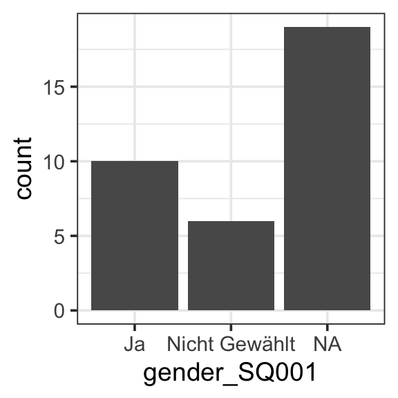

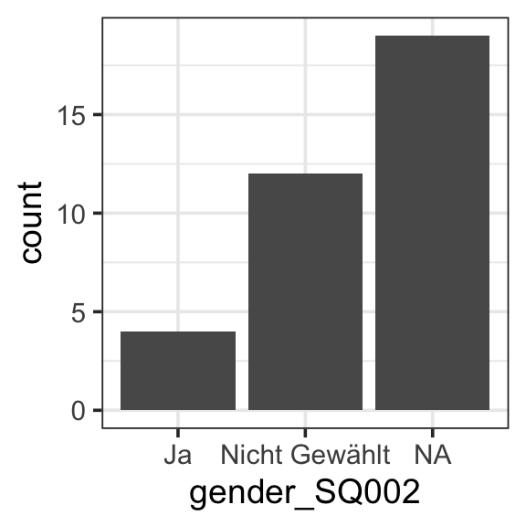

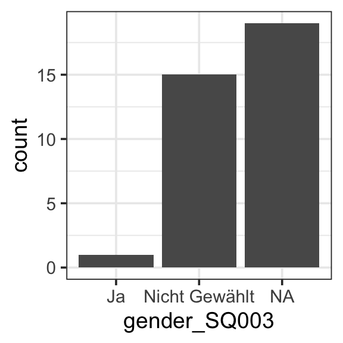

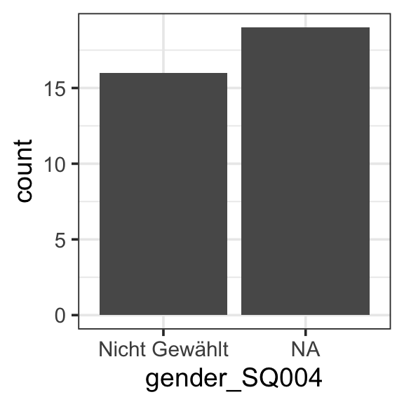

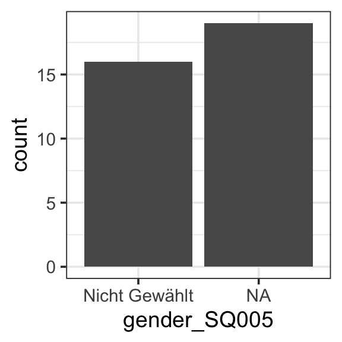

```r
barplot_mc(raw1, "gender")
```

Wir können uns mit der `frqplot_mc` Funktion alle Grafiken zusammengefügt angucken. Sortiert nach Variable:

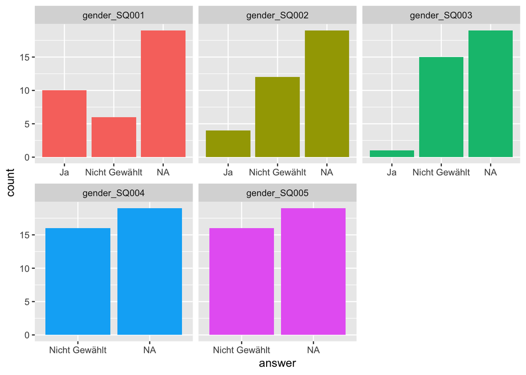

```r
frqplot_mc(raw1, "gender", version = 1)
```

und sortiert nach Antwort:

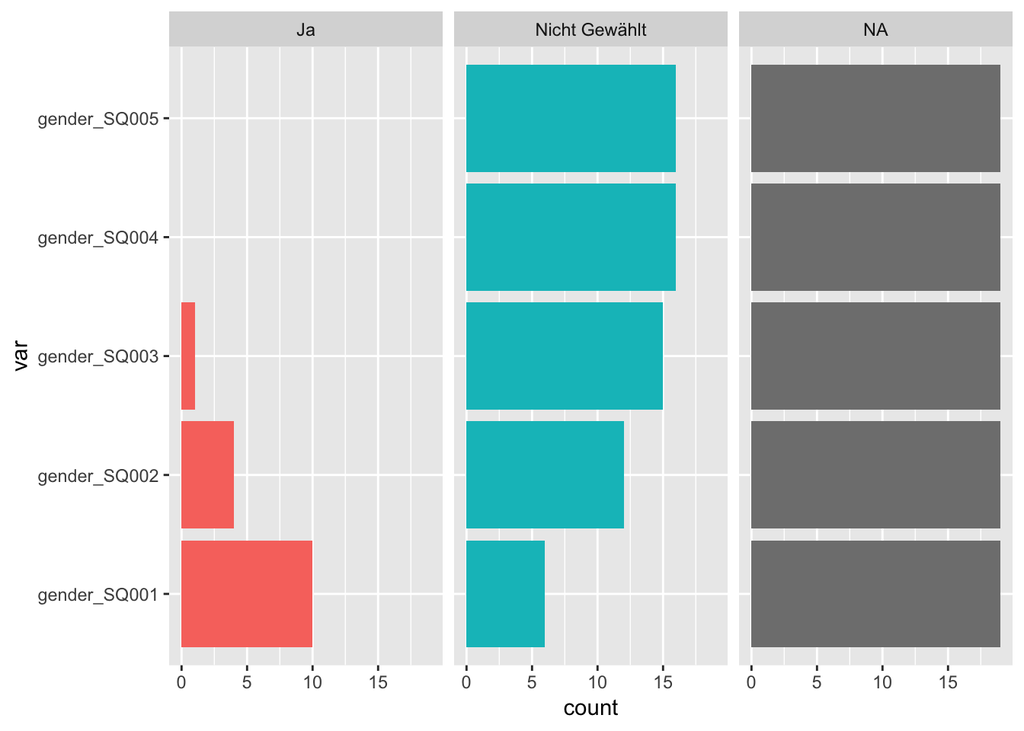

```r
frqplot_mc(raw1, "gender", version =  2)
```

### 1.1.3 Binär: Gender

**Generate New Variable**

Wir wollen eine Gender Variable `binary` erstellen, die in Binär vs. Non-Binär unterscheidet

```r
raw2 <- raw1 %>%
      mutate(binary = case_when(# binär = weiblich, männlich
                                    gender_SQ001 == "Ja" | gender_SQ002 == "Ja" ~ "binär",
                                  # non binär: divers, trans*, inter*
                                  # gender_SQ006 erstmal außen vor
                                    gender_SQ003 == "Ja" |
                                    gender_SQ004 == "Ja" |
                                    gender_SQ005 == "Ja"   ~ "nicht-binär",
                                  TRUE ~ NA_character_ ),
             binary = factor(binary, c("binär", "nicht-binär")),
             female = case_when(gender_SQ002 == "Ja" ~ "female",
                                gender_SQ003 == "Ja" ~ "male"),
             female = factor(female, c("female", "male"))
      )
```

Lets take a look!

```r
raw2 %>% janitor::tabyl(binary, female)
```

| binary | female | male | NA_ |
| --- | --- | --- | --- |
| binär | 4 | 0 | 9 |
| nicht-binär | 0 | 0 | 0 |
| NA | 0 | 0 | 22 |

```r
raw2 %>% skim(binary, female)
```

| variable | type | stat | level | value | formatted |
| --- | --- | --- | --- | --- | --- |
| binary | factor | missing | .all | 22 | 22 |
| binary | factor | complete | .all | 13 | 13 |
| binary | factor | n | .all | 35 | 35 |
| binary | factor | n_unique | .all | 1 | 1 |
| binary | factor | top_counts | NA | 22 | NA: 22 |
| binary | factor | top_counts | binär | 13 | bin: 13 |
| binary | factor | top_counts | nicht-binär | 0 | nic: 0 |
| binary | factor | ordered | .all | 0 | FALSE |
| female | factor | missing | .all | 31 | 31 |
| female | factor | complete | .all | 4 | 4 |
| female | factor | n | .all | 35 | 35 |
| female | factor | n_unique | .all | 1 | 1 |
| female | factor | top_counts | NA | 31 | NA: 31 |
| female | factor | top_counts | female | 4 | fem: 4 |
| female | factor | top_counts | male | 0 | mal: 0 |
| female | factor | ordered | .all | 0 | FALSE |

## 1.2 sexuelle Orientierung

Hier geht es um Informationen, die etwas mit der sexuelle Diskriminierungs-Dimension des Diversity Profils zu tun haben.

### 1.2.1 Info Raw Data

**Describe Raw Data**

Da haben wir zum Einen die Variablen, die das wort `sexo` im Variablennamen haben. Wir können uns mit der Funktion `frq_mc` die Häufigkeitstabellen für die Multiple Choice (_mc) Variablen einer Gruppe ausgeben lassen

```r
# raw1 %>% select_mc("gender") %>% View()

raw2 %>% frq_mc("sexo")
```

| var | Ja | Nicht Gewählt | NA_ |
| --- | --- | --- | --- |
| sexo_SQ001 | 0.09 | 0.31 | 0.6 |
| sexo_SQ002 | 0.06 | 0.34 | 0.6 |
| sexo_SQ003 | 0.00 | 0.40 | 0.6 |
| sexo_SQ004 | 0.00 | 0.40 | 0.6 |
| sexo_SQ005 | 0.26 | 0.14 | 0.6 |
| sexo_SQ006 | 0.03 | 0.37 | 0.6 |
| sexo_SQ007 | 0.06 | 0.34 | 0.6 |
| sexo_SQ008 | 0.00 | 0.40 | 0.6 |

```r
raw2 %>% frq_mc("sexo", 1)
```

| answer | sexo_SQ001 | sexo_SQ002 | sexo_SQ003 | sexo_SQ004 | sexo_SQ005 | sexo_SQ006 | sexo_SQ007 | sexo_SQ008 |
| --- | --- | --- | --- | --- | --- | --- | --- | --- |
| Ja | 3 | 2 | 0 | 0 | 9 | 1 | 2 | 0 |
| Nicht Gewählt | 11 | 12 | 14 | 14 | 5 | 13 | 12 | 14 |
| NA | 21 | 21 | 21 | 21 | 21 | 21 | 21 | 21 |

und wir können und auch die Value Labels der Variablen anzeigen lassen

```r
get_info(raw1, "sexo")
```

```
## Variable sexo_SQ001:
##  Value Label: [kann/ möchte ich nicht beantworten] Welche der folgenden Bezeichnungen beschreibt am besten Ihre sexuelle Orientierung/Identität?
##
##  Variable sexo_SQ002:
##  Value Label: [asexuell] Welche der folgenden Bezeichnungen beschreibt am besten Ihre sexuelle Orientierung/Identität?
##
##  Variable sexo_SQ003:
##  Value Label: [bisexuell] Welche der folgenden Bezeichnungen beschreibt am besten Ihre sexuelle Orientierung/Identität?
##
##  Variable sexo_SQ004:
##  Value Label: [lesbisch] Welche der folgenden Bezeichnungen beschreibt am besten Ihre sexuelle Orientierung/Identität?
##
##  Variable sexo_SQ005:
##  Value Label: [heterosexuell ] Welche der folgenden Bezeichnungen beschreibt am besten Ihre sexuelle Orientierung/Identität?
##
##  Variable sexo_SQ006:
##  Value Label: [homosexuell ] Welche der folgenden Bezeichnungen beschreibt am besten Ihre sexuelle Orientierung/Identität?
##
##  Variable sexo_SQ007:
##  Value Label: [queer] Welche der folgenden Bezeichnungen beschreibt am besten Ihre sexuelle Orientierung/Identität?
##
##  Variable sexo_SQ008:
##  Value Label: [schwul ] Welche der folgenden Bezeichnungen beschreibt am besten Ihre sexuelle Orientierung/Identität?
##
##  Variable sexo_other:
##  Value Label: [Sonstiges] Welche der folgenden Bezeichnungen beschreibt am besten Ihre sexuelle Orientierung/Identität?
##
```

### 1.2.2 Plot Raw Data

**Visualize Raw Data**

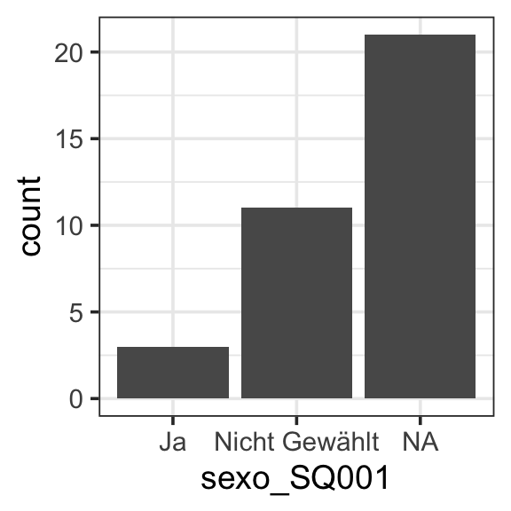

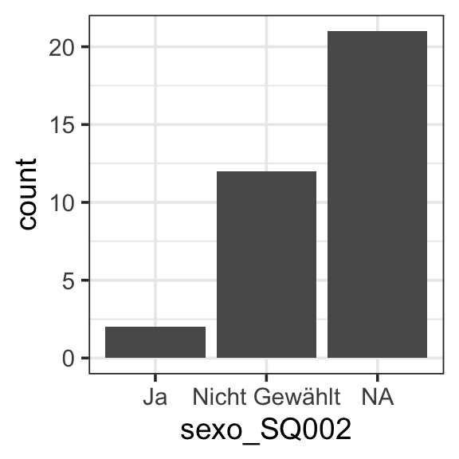

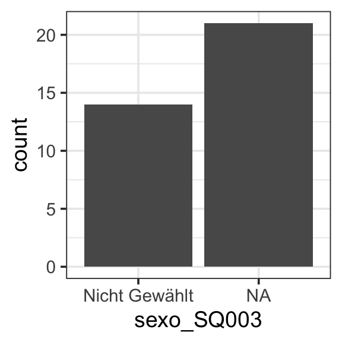

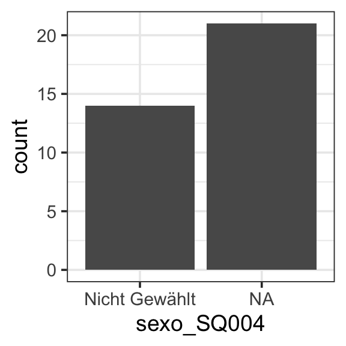

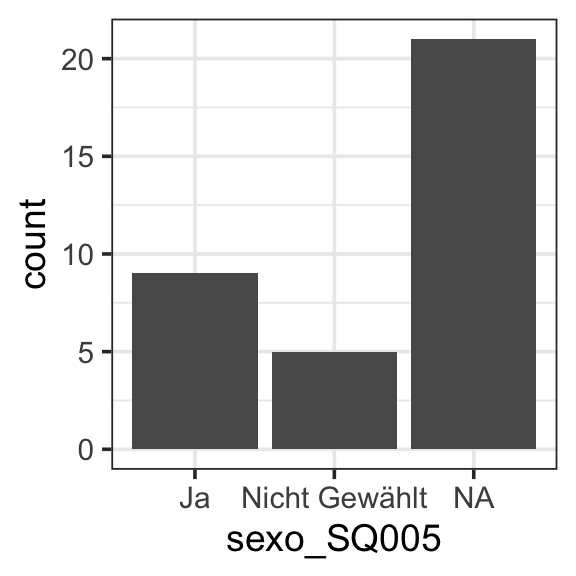

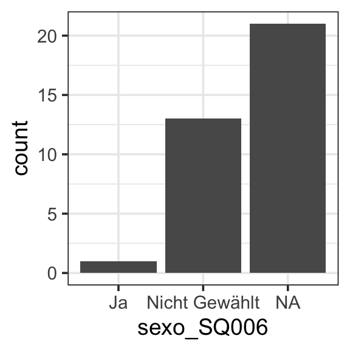

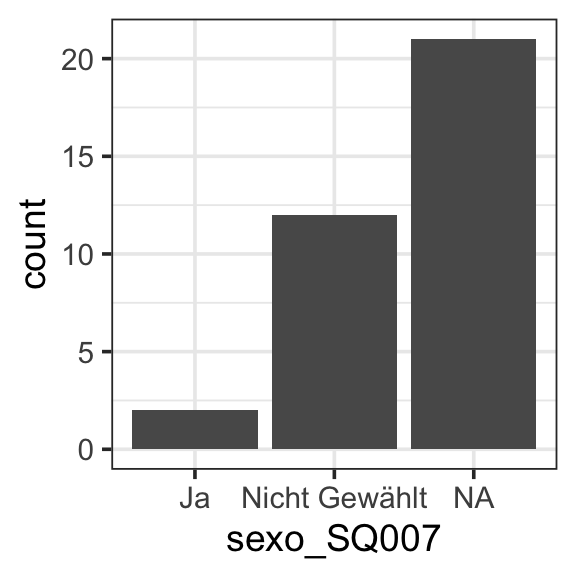

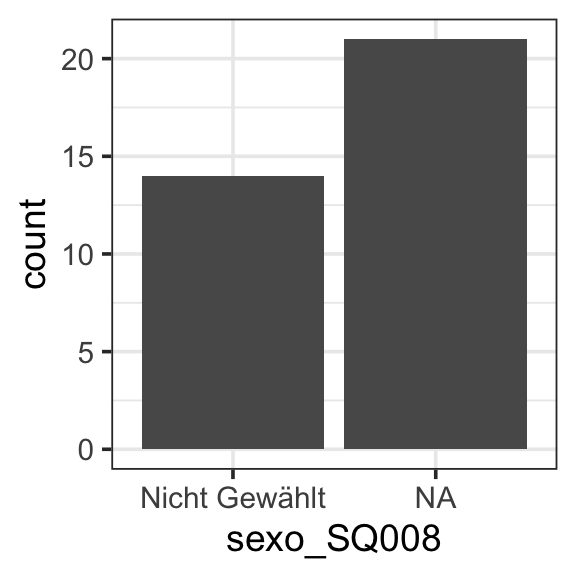

```r
barplot_mc(raw2, "sexo")
```

Wir können uns mit der `frqplot_mc` Funktion alle Grafiken zusammengefügt angucken. Einmal sortiert nach Variable:

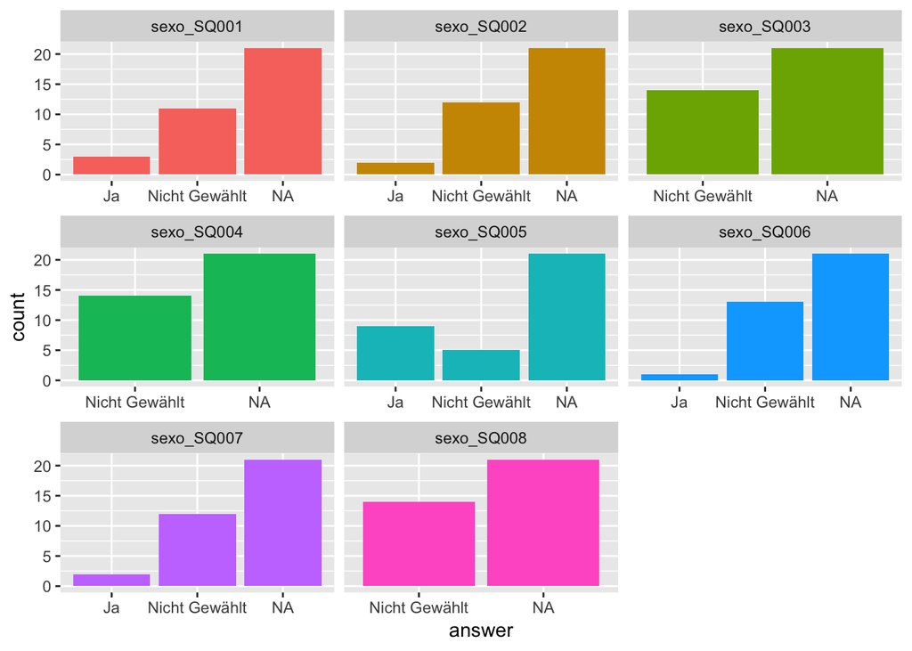

```r
frqplot_mc(raw2, "sexo")
```

Und einmal sortiert nach Antworten:

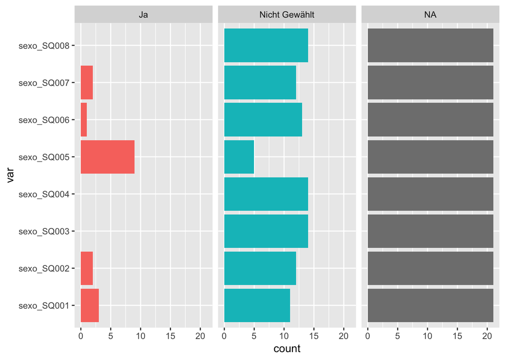

```r
frqplot_mc(raw1, "sexo", 2)
```

### 1.2.3 Binär: Sexuelle Orientierung

**Generate New Variable**

```
  Note: auch nach weiblich/männlich unterscheiden? #question
```

```r
raw3 <- raw2 %>%
      mutate(lgbtiq = case_when(# lgbtiq = bisexuell, lesbisch, homosexuell, queer, schwul
                                    sexo_SQ003 == "Ja" |
                                    sexo_SQ004 == "Ja" |
                                    sexo_SQ006 == "Ja" |
                                    sexo_SQ007 == "Ja" |
                                    sexo_SQ008 == "Ja" ~ "lgbtiq",
                                  # non binär: divers, trans*, inter*
                                  # gender_SQ006 erstmal außen vor
                                    # sexo_SQ002 == "Ja" | ???
                                    sexo_SQ005 == "Ja"   ~ "nicht-lgbtiq",
                                  TRUE ~ NA_character_ ),
             lgbtiq = factor(lgbtiq, c("lgbtiq", "nicht-lgbtiq"))
      )

raw3 %>% janitor::tabyl(lgbtiq)
```

| lgbtiq | n | percent | valid_percent |
| --- | --- | --- | --- |
| lgbtiq | 2 | 0.0571429 | 0.2 |
| nicht-lgbtiq | 8 | 0.2285714 | 0.8 |
| NA | 25 | 0.7142857 | NA |

## 1.3 Ost

Hier geht es um Informationen, die etwas mit der Dimension Ost des Diversity Profils zu tun haben

### 1.3.1 Info Raw Data

**Describe Raw Data**

Da haben wir zum Einen die Variablen, die das wort `gebort` im Variablennamen haben. Wir sehen, dass die Variable sehr lange Value Labels hat. Daher kürzen wir sie später um.

```r
# raw3 %>% select(gebort) %>% View()
# häufigkeiten anzeigen
raw3 %>% count(gebort)
```

| gebort | n |
| --- | --- |
| In der DDR (bis 3.10.1990); in den Bundesländern Brandenburg, Mecklenburg-Vorpommern, Sachsen, Sachsen-Anhalt, Thüringen | 11 |
| In den Bundesländern Baden-Württemberg, Bayern, Bremen, Hamburg, Hessen, Niedersachsen, Nordrhein-Westfalen, Rheinland-P | 2 |
| NA | 22 |

```r
#value labels des faktors anzeigen
levels(raw3$gebort)
```

```
## [1] "In der DDR (bis 3.10.1990); in den Bundesländern Brandenburg, Mecklenburg-Vorpommern, Sachsen, Sachsen-Anhalt, Thüringen"
## [2] "In den Bundesländern Baden-Württemberg, Bayern, Bremen, Hamburg, Hessen, Niedersachsen, Nordrhein-Westfalen, Rheinland-P"
## [3] "im Ausland"
```

### 1.3.2 Plot Raw Data

**Visualize Raw Data**

wir können das auch visualisieren

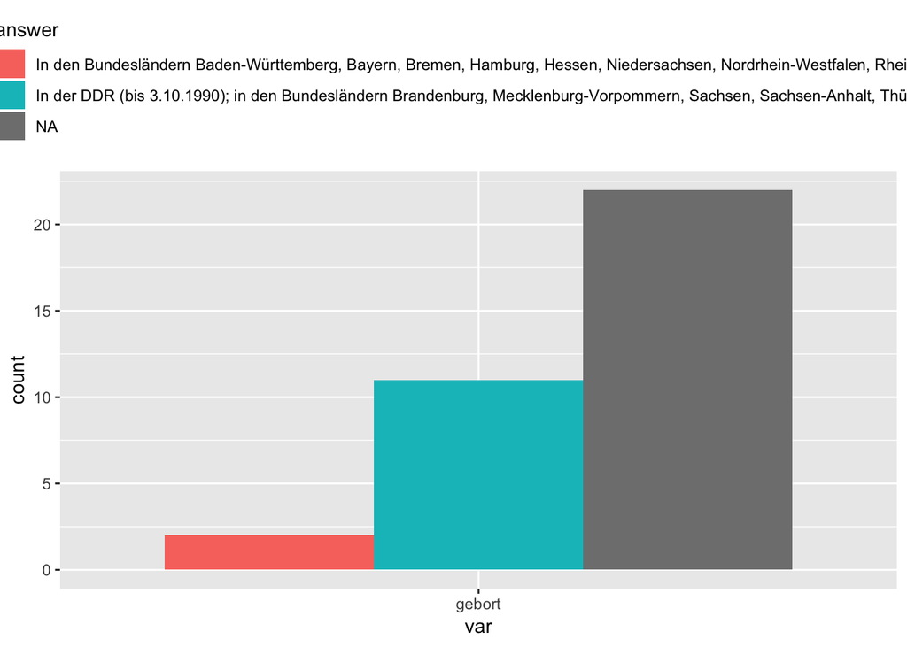

```r
raw3 %>%
      tidy_mc("gebort") %>%
      ggplot(aes(x = var, fill = answer)) +
      geom_bar(position = "dodge") +
      theme(legend.position = "top") +
      scale_fill_discrete(guide = guide_legend(nrow = 3, title.position = "top"))
```

### 1.3.3 Binär: Ost

**Generate New Variable**

Wir wollen eine Geburtsort Variable `ost` erstellen, die in Ost vs. West unterscheidet.

```r
raw4 <- raw3 %>%
      mutate(ost = case_when(grepl('DDR', gebort)  ~ "Ost",
                             grepl('Bayern', gebort) ~ "West",
                             TRUE ~ NA_character_),
             # aus dem Character Vector einen Faktor machen:
             ost = factor(ost, c("Ost", "West"))
             )

raw4 %>% tabyl(ost)
```

| ost | n | percent | valid_percent |
| --- | --- | --- | --- |
| Ost | 11 | 0.3142857 | 0.8461538 |
| West | 2 | 0.0571429 | 0.1538462 |
| NA | 22 | 0.6285714 | NA |

## 1.4 Age

Hier geht es um Informationen, die etwas mit der Alters-Dimension des Diversity Profils zu tun haben.

### 1.4.1 Info Raw Data

**Describe Raw Data**

Das Alter kann durch das Erhebungsjahr (2019) und das Geburtsjahr `gebjahr` erstellt werden.

```r
raw4 %>% select(gebjahr) %>% str()
```

```
## 'data.frame':    35 obs. of  1 variable:
##  $ gebjahr: Factor w/ 56 levels "1950","1951",..: NA NA NA NA NA NA NA 28 NA NA ...
```

```r
raw4 %>% tabyl(gebjahr) %>%
      adorn_rounding(digits = 2)
```

| gebjahr | n | percent | valid_percent |
| --- | --- | --- | --- |
| 1950 | 0 | 0.00 | 0.00 |
| 1951 | 0 | 0.00 | 0.00 |
| 1952 | 0 | 0.00 | 0.00 |
| 1953 | 0 | 0.00 | 0.00 |
| 1954 | 0 | 0.00 | 0.00 |
| 1955 | 0 | 0.00 | 0.00 |
| 1956 | 0 | 0.00 | 0.00 |
| 1957 | 0 | 0.00 | 0.00 |
| 1958 | 0 | 0.00 | 0.00 |
| 1959 | 1 | 0.03 | 0.08 |
| 1960 | 1 | 0.03 | 0.08 |
| 1961 | 1 | 0.03 | 0.08 |
| 1962 | 0 | 0.00 | 0.00 |
| 1963 | 1 | 0.03 | 0.08 |
| 1964 | 0 | 0.00 | 0.00 |
| 1965 | 0 | 0.00 | 0.00 |
| 1966 | 1 | 0.03 | 0.08 |
| 1967 | 0 | 0.00 | 0.00 |
| 1968 | 1 | 0.03 | 0.08 |
| 1969 | 0 | 0.00 | 0.00 |
| 1970 | 1 | 0.03 | 0.08 |
| 1971 | 1 | 0.03 | 0.08 |
| 1972 | 1 | 0.03 | 0.08 |
| 1973 | 0 | 0.00 | 0.00 |
| 1974 | 0 | 0.00 | 0.00 |
| 1975 | 0 | 0.00 | 0.00 |
| 1976 | 1 | 0.03 | 0.08 |
| 1977 | 1 | 0.03 | 0.08 |
| 1978 | 0 | 0.00 | 0.00 |
| 1979 | 2 | 0.06 | 0.15 |
| 1980 | 0 | 0.00 | 0.00 |
| 1981 | 0 | 0.00 | 0.00 |
| 1982 | 0 | 0.00 | 0.00 |
| 1983 | 0 | 0.00 | 0.00 |
| 1984 | 0 | 0.00 | 0.00 |
| 1985 | 0 | 0.00 | 0.00 |
| 1986 | 0 | 0.00 | 0.00 |
| 1987 | 0 | 0.00 | 0.00 |
| 1988 | 0 | 0.00 | 0.00 |
| 1989 | 0 | 0.00 | 0.00 |
| 1990 | 0 | 0.00 | 0.00 |
| 1991 | 0 | 0.00 | 0.00 |
| 1992 | 0 | 0.00 | 0.00 |
| 1993 | 0 | 0.00 | 0.00 |
| 1994 | 0 | 0.00 | 0.00 |
| 1995 | 0 | 0.00 | 0.00 |
| 1996 | 0 | 0.00 | 0.00 |
| 1997 | 0 | 0.00 | 0.00 |
| 1998 | 0 | 0.00 | 0.00 |
| 1999 | 0 | 0.00 | 0.00 |
| 2000 | 0 | 0.00 | 0.00 |
| 2001 | 0 | 0.00 | 0.00 |
| 2002 | 0 | 0.00 | 0.00 |
| 2003 | 0 | 0.00 | 0.00 |
| 2004 | 0 | 0.00 | 0.00 |
| 2005 | 0 | 0.00 | 0.00 |
| NA | 22 | 0.63 | NA |

Wir sehen, dass es ein Faktor ist, obwohl es eigentlich besser durch eine numerische variable dargestellt wird. Das ändern wir später.

### 1.4.2 Plot Raw Data

**Visualize Raw Data**

Altersstruktur als Plot

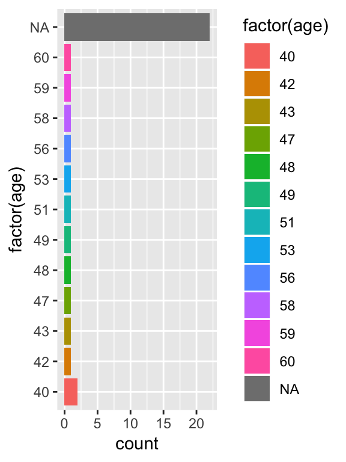

```r
raw4 %>%
      mutate(age = 2019 - as.numeric(as.character(gebjahr))) %>%
      ggplot(aes(factor(age), fill = factor(age))) +
      geom_bar(position = "dodge") +
      coord_flip()
```

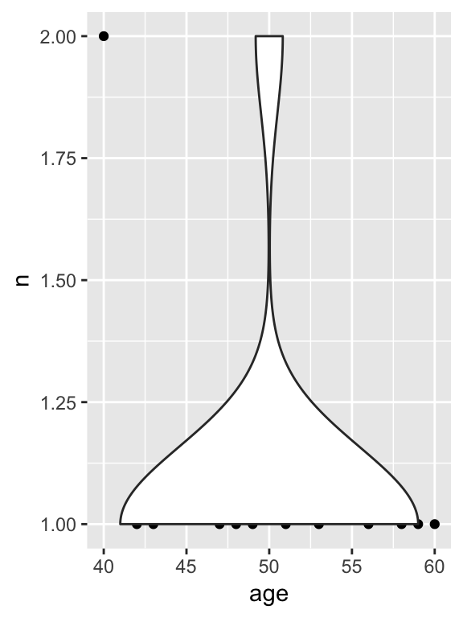

```r
raw4 %>%
      mutate(age = 2019 - as.numeric(as.character(gebjahr))) %>%
      count(age) %>%
      drop_na(age) %>%
      ggplot(aes(age, n)) +
      geom_point() +
      geom_violin()
```

### 1.4.3 Age

**Generate New Variable**

```r
raw5 <- raw4 %>%
      mutate(age = 2019 - as.numeric(as.character(gebjahr)))
```

Check out the new Variable!

```r
raw5 %>% count(age)
```

| age | n |
| --- | --- |
| 40 | 2 |
| 42 | 1 |
| 43 | 1 |
| 47 | 1 |
| 48 | 1 |
| 49 | 1 |
| 51 | 1 |
| 53 | 1 |
| 56 | 1 |
| 58 | 1 |
| 59 | 1 |
| 60 | 1 |
| NA | 22 |

## 1.5 Migrationshintergrund

Hier geht es um Informationen, die etwas mit der Dimension Migrationshintergrund zu tun haben:

### 1.5.1 Info Raw Data

**Describe Raw Data**

Wir sehen, dass die Variable wieder sehr lange Value Labels hat.

```r
raw5 %>% count(mh)
```

| mh | n |
| --- | --- |
| Mindestens ein Elternteil ist nach 1955 auf das heutige Gebiet der Bundesrepublik Deutschland zugewandert, eingebürgert | 1 |
| Mindestens ein Großelternteil mit deutscher Staatszugehörigkeit und Wohnsitz in den früheren deutschen Ostgebieten, ist | 6 |
| Nichts davon trifft zu. | 6 |
| NA | 22 |

wir lassen uns die kompletten Value Labels anzeigen

```r
levels(raw5$mh)
```

```
## [1] "Sie selbst sind nach 1955 auf das heutige Gebiet der Bundesrepublik Deutschland zugewandert, eingebürgert oder haben ein"
## [2] "Mindestens ein Elternteil ist nach 1955 auf das heutige Gebiet der Bundesrepublik Deutschland zugewandert, eingebürgert "
## [3] "Mindestens ein Großelternteil ist nach 1955 aus einem anderen Land auf das heutige Gebiet der Bundesrepublik zugewandert"
## [4] "Sie selbst sind als Schutzsuchende unter Berufung auf humanitäre Gründe nach Deutschland geflohen."
## [5] "Mindestens ein Elternteil ist als Schutzsuchende unter Berufung auf humanitäre Gründe nach Deutschland geflohen."
## [6] "Mindestens ein Großelternteil ist als Schutzsuchende unter Berufung auf humanitäre Gründe nach Deutschland geflohen."
## [7] "Mindestens ein Großelternteil mit deutscher Staatszugehörigkeit und Wohnsitz in den früheren deutschen Ostgebieten, ist "
## [8] "Nichts davon trifft zu."
```

### 1.5.2 Plot Raw Data

**Visualize Raw Data**

Eine Visualisierung, die das Anzeigen der langen Labels ermöglicht:

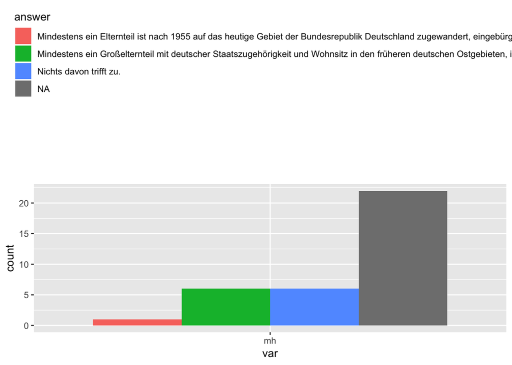

```r
raw5 %>%
      select(id, mh) %>%
      gather(var, answer, -id) %>%
      ggplot(aes(x = var, fill = answer)) +
      geom_bar(position = "dodge") +
      theme(legend.position = "top") +
      scale_fill_discrete(guide = guide_legend(nrow = 8, title.position = "top"))
```

### 1.5.3 Binär: Migrationshintergrund

**Generate New Variable**

Jetzt generieren wir Variablen:

```
  - die dichotome Variable für Migrationshintergrund `mh_d` und
  - die Migrationsvariable, die sich auf die Generation bezieht `mhgen` und
  - die Fluchtvariable, die sich auf die Generation bezieht `refugen`
```

```r
raw6 <- raw5 %>%
      mutate(# Dichotome Migrationsvariable erstellen
             mh_d = case_when(grepl(levels(raw5$mh)[1], mh)  |
                              grepl(levels(raw5$mh)[2], mh)  |
                              grepl(levels(raw5$mh)[3], mh)  |
                              grepl(levels(raw5$mh)[4], mh)  |
                              grepl(levels(raw5$mh)[5], mh)  |
                              grepl(levels(raw5$mh)[6], mh)  ~ "Migrationshintergrund",
                              grepl(levels(raw5$mh)[7], mh)  ~ "kein Migrationshintergrund",
                             TRUE ~ NA_character_),
             # aus dem Character Vector einen Faktor machen:
             mh_d = factor(mh_d, c("Migrationshintergrund", "kein Migrationshintergrund")),
             # Migration nach Generation generieren
             mh_gen = case_when(grepl(levels(raw5$mh)[1], mh) ~ "1. Generation",
                                grepl(levels(raw5$mh)[2], mh) ~ "2. Generation",
                                grepl(levels(raw5$mh)[3], mh) ~ "3. Generation",
                                TRUE ~ NA_character_),
             mh_gen = factor(mh_gen, c("1. Generation", "2. Generation", "3. Generation")),
             # refugee nach Generation generieren
             refu_gen = case_when(grepl(levels(raw5$mh)[4], mh) ~ "1. Generation",
                                  grepl(levels(raw5$mh)[5], mh) ~ "2. Generation",
                                  grepl(levels(raw5$mh)[6], mh) ~ "3. Generation",
                                TRUE ~ NA_character_),
             refu_gen = factor(refu_gen, c("1. Generation", "2. Generation", "3. Generation")),
             vertriebene  = case_when(grepl(levels(raw5$mh)[7], mh) ~ "1. Generation",
                                      TRUE ~ NA_character_),
             vertriebene = factor(vertriebene, c("Vertriebene"))
             )

raw6 %>% skim(contains("mh"), -contains("mhandab"), refu_gen, vertriebene)
```

| variable | type | stat | level | value | formatted |
| --- | --- | --- | --- | --- | --- |
| mh | factor | missing | .all | 22 | 22 |
| mh | factor | complete | .all | 13 | 13 |
| mh | factor | n | .all | 35 | 35 |
| mh | factor | n_unique | .all | 3 | 3 |
| mh | factor | top_counts | NA | 22 | NA: 22 |
| mh | factor | top_counts | Mindestens ein Großelternteil mit deutscher Staatszugehörigkeit und Wohnsitz in den früheren deutschen Ostgebieten, ist | 6 | Min: 6 |
| mh | factor | top_counts | Nichts davon trifft zu. | 6 | Nic: 6 |
| mh | factor | top_counts | Mindestens ein Elternteil ist nach 1955 auf das heutige Gebiet der Bundesrepublik Deutschland zugewandert, eingebürgert | 1 | Min: 1 |
| mh | factor | top_counts | Sie selbst sind nach 1955 auf das heutige Gebiet der Bundesrepublik Deutschland zugewandert, eingebürgert oder haben ein | 0 | Sie: 0 |
| mh | factor | top_counts | Mindestens ein Großelternteil ist nach 1955 aus einem anderen Land auf das heutige Gebiet der Bundesrepublik zugewandert | 0 | Min: 0 |
| mh | factor | top_counts | Sie selbst sind als Schutzsuchende unter Berufung auf humanitäre Gründe nach Deutschland geflohen. | 0 | Sie: 0 |
| mh | factor | top_counts | Mindestens ein Elternteil ist als Schutzsuchende unter Berufung auf humanitäre Gründe nach Deutschland geflohen. | 0 | Min: 0 |
| mh | factor | top_counts | Mindestens ein Großelternteil ist als Schutzsuchende unter Berufung auf humanitäre Gründe nach Deutschland geflohen. | 0 | Min: 0 |
| mh | factor | ordered | .all | 0 | FALSE |
| mh_d | factor | missing | .all | 28 | 28 |
| mh_d | factor | complete | .all | 7 | 7 |
| mh_d | factor | n | .all | 35 | 35 |
| mh_d | factor | n_unique | .all | 2 | 2 |
| mh_d | factor | top_counts | NA | 28 | NA: 28 |
| mh_d | factor | top_counts | kein Migrationshintergrund | 6 | kei: 6 |
| mh_d | factor | top_counts | Migrationshintergrund | 1 | Mig: 1 |
| mh_d | factor | ordered | .all | 0 | FALSE |
| mh_gen | factor | missing | .all | 34 | 34 |
| mh_gen | factor | complete | .all | 1 | 1 |
| mh_gen | factor | n | .all | 35 | 35 |
| mh_gen | factor | n_unique | .all | 1 | 1 |
| mh_gen | factor | top_counts | NA | 34 | NA: 34 |
| mh_gen | factor | top_counts | 2. Generation | 1 | 2. : 1 |
| mh_gen | factor | top_counts | 1. Generation | 0 | 1. : 0 |
| mh_gen | factor | top_counts | 3. Generation | 0 | 3. : 0 |
| mh_gen | factor | ordered | .all | 0 | FALSE |
| refu_gen | factor | missing | .all | 35 | 35 |
| refu_gen | factor | complete | .all | 0 | 0 |
| refu_gen | factor | n | .all | 35 | 35 |
| refu_gen | factor | n_unique | .all | 0 | 0 |
| refu_gen | factor | top_counts | NA | 35 | NA: 35 |
| refu_gen | factor | top_counts | 1. Generation | 0 | 1. : 0 |
| refu_gen | factor | top_counts | 2. Generation | 0 | 2. : 0 |
| refu_gen | factor | top_counts | 3. Generation | 0 | 3. : 0 |
| refu_gen | factor | ordered | .all | 0 | FALSE |
| vertriebene | factor | missing | .all | 35 | 35 |
| vertriebene | factor | complete | .all | 0 | 0 |
| vertriebene | factor | n | .all | 35 | 35 |
| vertriebene | factor | n_unique | .all | 0 | 0 |
| vertriebene | factor | top_counts | NA | 35 | NA: 35 |
| vertriebene | factor | top_counts | Vertriebene | 0 | Ver: 0 |
| vertriebene | factor | ordered | .all | 0 | FALSE |

```r
# raw6 %>% select(contains("mh"), -contains("mhandab"), refu_gen, vertriebene) %>% View()
```

## 1.6 Rassistische Diskriminierung

Hier geht es um Informationen, die etwas mit der Dimension rassistische Diskriminierung des Diversity Profils zu tun haben

Die Variable rassistische Diskriminierung wird durch mehrere der Variblen in den Roh-Daten erstellt

1. allgemeine Diskriminierung ethnische Herkunft/rassistische Gründe: `diskallgRass == c(1,2)`
2. befristeter Aufenthalt: `diskallgBefr == c(1,2)`
3. Fremdwahrnehmung und Merkmal: `fremdwahr == c(3,5)` UND `fremdwahrbez == 1 OR 7`
4. Selbstbezeichnung `selbstbez == c(2,3,5,7,8,9,10, 11,12,20)`

### 1.6.1 Info Raw Data

**Describe Raw Data**

#### 1.6.1.1 1. allgemeine Diskriminierung:

ersteinmal herausfinden, welche der `diskallg` Variablen sich auf rassistische Diskriminierung und den befristeten Aufenthaltsstatus beziehen:

Dafür müssen wir aus die Variablen Labels zurückgreifen, da die Variablennamen nichts aussagen

```r
rassdisk_subset <- raw1[,grepl("diskallg", attributes(raw1)$names) &
                         grepl("Ethnische Herkunft|Befristeter Aufenthaltstitel",
                               attributes(raw1)$variable.labels)]
# rassdisk_subset %>% View()

cat(paste0("Variable ",
       names(raw1)[grepl("diskallg", attributes(raw1)$names) &
                         grepl("Ethnische Herkunft|Befristeter Aufenthaltstite", attributes(raw1)$variable.labels)], ": \n",
       attributes(raw1)$variable.labels[grepl("diskallg", attributes(raw1)$names) &
                         grepl("Ethnische Herkunft|Befristeter Aufenthaltstite", attributes(raw1)$variable.labels)]," \n \n")
    )
```

```
## Variable diskallg_SQ005_A1:
## [Ethnische Herkunft/ rassistische Gründe  ] [Diskriminierung im Arbeitskontext] Bitte geben Sie an, in Bezug auf welche Merkmale Sie in den letzten 5 Jahren in Deutschland diskriminiert wurden. Sie können dabei zwischen Diskriminierung im Arbeitskontext– und außerhalb des Arbeitskontextes untersc…
##
##  Variable diskallg_SQ005_A2:
## [Ethnische Herkunft/ rassistische Gründe  ] [Diskriminierung außerhalb des Arbeitskontextes] Bitte geben Sie an, in Bezug auf welche Merkmale Sie in den letzten 5 Jahren in Deutschland diskriminiert wurden. Sie können dabei zwischen Diskriminierung im Arbeitskontext– und außerhalb des Arbeitskont…
##
##  Variable diskallg_SQ016_A1:
## [Befristeter Aufenthaltstitel  ] [Diskriminierung im Arbeitskontext] Bitte geben Sie an, in Bezug auf welche Merkmale Sie in den letzten 5 Jahren in Deutschland diskriminiert wurden. Sie können dabei zwischen Diskriminierung im Arbeitskontext– und außerhalb des Arbeitskontextes unterscheiden.  Di…
##
##  Variable diskallg_SQ016_A2:
## [Befristeter Aufenthaltstitel  ] [Diskriminierung außerhalb des Arbeitskontextes] Bitte geben Sie an, in Bezug auf welche Merkmale Sie in den letzten 5 Jahren in Deutschland diskriminiert wurden. Sie können dabei zwischen Diskriminierung im Arbeitskontext– und außerhalb des Arbeitskontextes unter…
##
```

Jetzt können wir die Häufigkeiten ausgeben

```r
rassdisk_frq <- raw6 %>%
      select(id, names(rassdisk_subset)) %>%
      mutate_if(is.factor, ~as.numeric(as.character(.))) %>%
      gather(key = var, value = answer , -id) %>%
      arrange(id)

rassdisk_frq %>% tabyl(answer, var)
```

| answer | diskallg_SQ005_A1 | diskallg_SQ005_A2 | diskallg_SQ016_A1 | diskallg_SQ016_A2 |
| --- | --- | --- | --- | --- |
| NA | 35 | 35 | 35 | 35 |

```r
rassdisk_frq %>% tabyl(var, answer) %>%
      adorn_percentages() %>%
      adorn_rounding(digits = 2)
```

| var | NA_ |
| --- | --- |
| diskallg_SQ005_A1 | 1 |
| diskallg_SQ005_A2 | 1 |
| diskallg_SQ016_A1 | 1 |
| diskallg_SQ016_A2 | 1 |

#### 1.6.1.2 2. Fremdwahrnehmung

Weiter zur Fremdwahrnehmung:

Hier gibt es eine Generelle Frage zur Fremdwahrnehmung `fremdwahr`.

```r
raw6 %>% select(contains("fremdwahr")) %>% skim()
```

| variable | type | stat | level | value | formatted |
| --- | --- | --- | --- | --- | --- |
| fremdwahr | factor | missing | .all | 23 | 23 |
| fremdwahr | factor | complete | .all | 12 | 12 |
| fremdwahr | factor | n | .all | 35 | 35 |
| fremdwahr | factor | n_unique | .all | 3 | 3 |
| fremdwahr | factor | top_counts | NA | 23 | NA: 23 |
| fremdwahr | factor | top_counts | nie | 10 | nie: 10 |
| fremdwahr | factor | top_counts | gelegentlich | 1 | gel: 1 |
| fremdwahr | factor | top_counts | oft | 1 | oft: 1 |
| fremdwahr | factor | top_counts | selten | 0 | sel: 0 |
| fremdwahr | factor | top_counts | (fast) immer | 0 | (fa: 0 |
| fremdwahr | factor | ordered | .all | 0 | FALSE |
| fremdwahrbez_w1 | factor | missing | .all | 33 | 33 |
| fremdwahrbez_w1 | factor | complete | .all | 2 | 2 |
| fremdwahrbez_w1 | factor | n | .all | 35 | 35 |
| fremdwahrbez_w1 | factor | n_unique | .all | 1 | 1 |
| fremdwahrbez_w1 | factor | top_counts | NA | 33 | NA: 33 |
| fremdwahrbez_w1 | factor | top_counts | Nicht Gewählt | 2 | Nic: 2 |
| fremdwahrbez_w1 | factor | top_counts | Ja | 0 | Ja: 0 |
| fremdwahrbez_w1 | factor | ordered | .all | 0 | FALSE |
| fremdwahrbez_w2 | factor | missing | .all | 33 | 33 |
| fremdwahrbez_w2 | factor | complete | .all | 2 | 2 |
| fremdwahrbez_w2 | factor | n | .all | 35 | 35 |
| fremdwahrbez_w2 | factor | n_unique | .all | 2 | 2 |
| fremdwahrbez_w2 | factor | top_counts | NA | 33 | NA: 33 |
| fremdwahrbez_w2 | factor | top_counts | Ja | 1 | Ja: 1 |
| fremdwahrbez_w2 | factor | top_counts | Nicht Gewählt | 1 | Nic: 1 |
| fremdwahrbez_w2 | factor | ordered | .all | 0 | FALSE |
| fremdwahrbez_w3 | factor | missing | .all | 33 | 33 |
| fremdwahrbez_w3 | factor | complete | .all | 2 | 2 |
| fremdwahrbez_w3 | factor | n | .all | 35 | 35 |

[output cut: 60 more lines]

```r
raw6 %>% tabyl(fremdwahr) %>%
      adorn_rounding(digits = 2)
```

| fremdwahr | n | percent | valid_percent |
| --- | --- | --- | --- |
| nie | 10 | 0.29 | 0.83 |
| selten | 0 | 0.00 | 0.00 |
| gelegentlich | 1 | 0.03 | 0.08 |
| oft | 1 | 0.03 | 0.08 |
| (fast) immer | 0 | 0.00 | 0.00 |
| NA | 23 | 0.66 | NA |

Danach wird erfragt, auf was sich die Diskriminierung bezieht. `fremdwahrbez_SQ001-9` Für diese Variablen müssen wir ersteinmal herausfinden, welche der Variablen sich auf rassistische Diskriminierung und den befristeten Aufenthaltsstatus beziehen:

Dafür müssen wir aus die Variablen Labels zurückgreifen, da die Variablennamen nichts aussagen

```r
fremdwahrbez_subset <- raw1[,grepl("fremdwahr", attributes(raw1)$names) &
                         grepl("Hautfarbe|religiösen", attributes(raw1)$variable.labels)]
# fremdwahrbez_subset %>% View()

cat(paste0(
      "Variable ",
      names(fremdwahrbez_subset),
      ": \n", " Value Label: ",
      attributes(raw1)$variable.labels[
            grepl("fremdwahr", attributes(raw1)$names) &
            grepl("Hautfarbe|religiösen",
            attributes(raw1)$variable.labels)]
      ," \n \n")
    )
```

```
## Variable fremdwahrbez_w1:
##  Value Label: [wegen meiner „Hautfarbe"] Was glauben Sie, in Bezug auf welches Merkmal wurden Sie als „fremd“ oder „nicht weiß“ wahrgenommen?
##
##  Variable fremdwahrbez_w4:
##  Value Label: [wegen meiner religiösen Kopfbedeckung] Was glauben Sie, in Bezug auf welches Merkmal wurden Sie als „fremd“ oder „nicht weiß“ wahrgenommen?
##
```

Jetzt können wir die Häufigkeiten ausgeben

```r
fremdwahrbez_frq <- raw6 %>%
      select(id, names(fremdwahrbez_subset)) %>%
      mutate_if(is.factor, ~ as.numeric(as.character(.))) %>%
      gather(key = var, value = answer , -id) %>%
      arrange(id)

fremdwahrbez_frq %>% tabyl(answer, var)
```

| answer | fremdwahrbez_w1 | fremdwahrbez_w4 |
| --- | --- | --- |
| NA | 35 | 35 |

```r
fremdwahrbez_frq %>% tabyl(var, answer) %>%
      adorn_percentages() %>%
      adorn_rounding(digits = 2)
```

| var | NA_ |
| --- | --- |
| fremdwahrbez_w1 | 1 |
| fremdwahrbez_w4 | 1 |

#### 1.6.1.3 3. Selbstbezeichnung

ersteinmal herausfinden, welche der `selbstbez_SQ00` Variablen sich auf rassistische Diskriminierung und den befristeten Aufenthaltsstatus beziehen:

Dafür müssen wir aus die Variablen Labels zurückgreifen, da die Variablennamen nichts aussagen

```r
selbstbez_find <- c("Person of Colour", "Schwarz", "\\[Jüdisch",
                     "Muslimisch", "Sinti und Roma", "Afrodeutsch",
                     "Vietnamesisch-Deutsch", "Arabisch", "Asiatisch-Deutsch",
                     "Türkisch-Deutsch")

selbstbez_subset <- raw1[, grepl("selbstbez", attributes(raw1)$names) &
                           grepl(paste(selbstbez_find, collapse = "|"),
                                 attributes(raw1)$variable.labels)
                         ]

# selbstbez_subset %>% View()

cat(paste0(
      "Variable ",
      names(raw1)[
             grepl("selbstbez", attributes(raw1)$names) &
                   grepl(paste(selbstbez_find, collapse = "|"),
                         attributes(raw1)$variable.labels)],
      ": \n", " Value Label: ",
       attributes(raw1)$variable.labels[
             grepl("selbstbez", attributes(raw1)$names) &
                   grepl(paste(selbstbez_find, collapse = "|"),
                         attributes(raw1)$variable.labels)]," \n \n")
    )
```

```
## Variable selbstbez_SQ002:
##  Value Label: [Person of Colour ] Welche der folgenden (Selbst-)Bezeichnungen trifft am ehesten auf Sie zu?  Diese Liste orientiert sich an den geografischen Bezügen und Selbstbezeichnungen von zahlenmäßig großen Gruppen in Deutschland und Thüringen sowie an den nach der UN-Antirassismuskonventio…
##
##  Variable selbstbez_SQ003:
##  Value Label: [Schwarz] Welche der folgenden (Selbst-)Bezeichnungen trifft am ehesten auf Sie zu?  Diese Liste orientiert sich an den geografischen Bezügen und Selbstbezeichnungen von zahlenmäßig großen Gruppen in Deutschland und Thüringen sowie an den nach der UN-Antirassismuskonvention schutzwü…
##
##  Variable selbstbez_SQ008:
##  Value Label: [Afrodeutsch] Welche der folgenden (Selbst-)Bezeichnungen trifft am ehesten auf Sie zu?  Diese Liste orientiert sich an den geografischen Bezügen und Selbstbezeichnungen von zahlenmäßig großen Gruppen in Deutschland und Thüringen sowie an den nach der UN-Antirassismuskonvention schu…
##
##  Variable selbstbez_SQ004:
##  Value Label: [Jüdisch] Welche der folgenden (Selbst-)Bezeichnungen trifft am ehesten auf Sie zu?  Diese Liste orientiert sich an den geografischen Bezügen und Selbstbezeichnungen von zahlenmäßig großen Gruppen in Deutschland und Thüringen sowie an den nach der UN-Antirassismuskonvention schutzwü…
##
##  Variable selbstbez_SQ006:
##  Value Label: [Muslimisch] Welche der folgenden (Selbst-)Bezeichnungen trifft am ehesten auf Sie zu?  Diese Liste orientiert sich an den geografischen Bezügen und Selbstbezeichnungen von zahlenmäßig großen Gruppen in Deutschland und Thüringen sowie an den nach der UN-Antirassismuskonvention schut…
##
##  Variable selbstbez_SQ007:
##  Value Label: [Sinti und Roma] Welche der folgenden (Selbst-)Bezeichnungen trifft am ehesten auf Sie zu?  Diese Liste orientiert sich an den geografischen Bezügen und Selbstbezeichnungen von zahlenmäßig großen Gruppen in Deutschland und Thüringen sowie an den nach der UN-Antirassismuskonvention s…
##
##  Variable selbstbez_SQ014:
##  Value Label: [Vietnamesisch-Deutsch] Welche der folgenden (Selbst-)Bezeichnungen trifft am ehesten auf Sie zu?  Diese Liste orientiert sich an den geografischen Bezügen und Selbstbezeichnungen von zahlenmäßig großen Gruppen in Deutschland und Thüringen sowie an den nach der UN-Antirassismuskonve…
##
##  Variable selbstbez_SQ010:
##  Value Label: [Asiatisch-Deutsch] Welche der folgenden (Selbst-)Bezeichnungen trifft am ehesten auf Sie zu?  Diese Liste orientiert sich an den geografischen Bezügen und Selbstbezeichnungen von zahlenmäßig großen Gruppen in Deutschland und Thüringen sowie an den nach der UN-Antirassismuskonventio…
##
##  Variable selbstbez_SQ009:
##  Value Label: [Arabisch] Welche der folgenden (Selbst-)Bezeichnungen trifft am ehesten auf Sie zu?  Diese Liste orientiert sich an den geografischen Bezügen und Selbstbezeichnungen von zahlenmäßig großen Gruppen in Deutschland und Thüringen sowie an den nach der UN-Antirassismuskonvention schutzw…
##
##  Variable selbstbez_SQ013:
##  Value Label: [Türkisch-Deutsch] Welche der folgenden (Selbst-)Bezeichnungen trifft am ehesten auf Sie zu?  Diese Liste orientiert sich an den geografischen Bezügen und Selbstbezeichnungen von zahlenmäßig großen Gruppen in Deutschland und Thüringen sowie an den nach der UN-Antirassismuskonvention…
##
```

Jetzt können wir die Häufigkeiten ausgeben

```r
selbstbez_frq <- raw6 %>%
      select(id, names(selbstbez_subset)) %>%
      mutate_if(is.factor, ~ as.numeric(as.character(.))) %>%
      gather(key = var, value = answer , -id) %>%
      arrange(id)

selbstbez_frq %>% tabyl(answer, var)
```

| answer | selbstbez_SQ002 | selbstbez_SQ003 | selbstbez_SQ004 | selbstbez_SQ006 | selbstbez_SQ007 | selbstbez_SQ008 | selbstbez_SQ009 | selbstbez_SQ010 | selbstbez_SQ013 | selbstbez_SQ014 |
| --- | --- | --- | --- | --- | --- | --- | --- | --- | --- | --- |
| NA | 35 | 35 | 35 | 35 | 35 | 35 | 35 | 35 | 35 | 35 |

```r
selbstbez_frq %>% tabyl(var, answer) %>%
      adorn_percentages() %>%
      adorn_rounding(digits = 2)
```

| var | NA_ |
| --- | --- |
| selbstbez_SQ002 | 1 |
| selbstbez_SQ003 | 1 |
| selbstbez_SQ004 | 1 |
| selbstbez_SQ006 | 1 |
| selbstbez_SQ007 | 1 |
| selbstbez_SQ008 | 1 |
| selbstbez_SQ009 | 1 |
| selbstbez_SQ010 | 1 |
| selbstbez_SQ013 | 1 |
| selbstbez_SQ014 | 1 |

### 1.6.2 Plot Raw Data

**Visualize Raw Data**

#### 1.6.2.1 1. allgemeine Diskriminierung

[figure not shown]

```r
rassdisk_frq %>%
      ggplot(aes(x = answer, fill = var)) +
      geom_bar(position = "dodge") +
      facet_wrap(~ var, scales = "free_x") +
      theme(legend.position = "none")
```

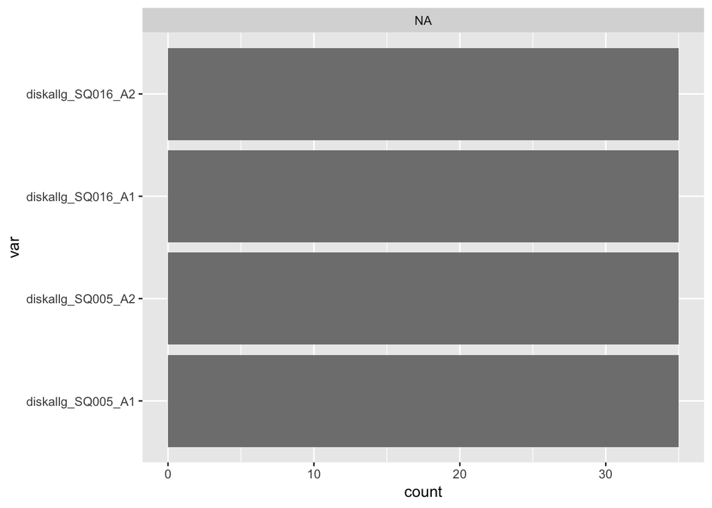

```r
rassdisk_frq %>%
      ggplot(aes(x = var, fill = answer)) +
      geom_bar(position = "dodge") +
      facet_wrap(~ answer) +
      coord_flip() +
      theme(legend.position = "none")
```

#### 1.6.2.2 2. Fremdwahrnehmung

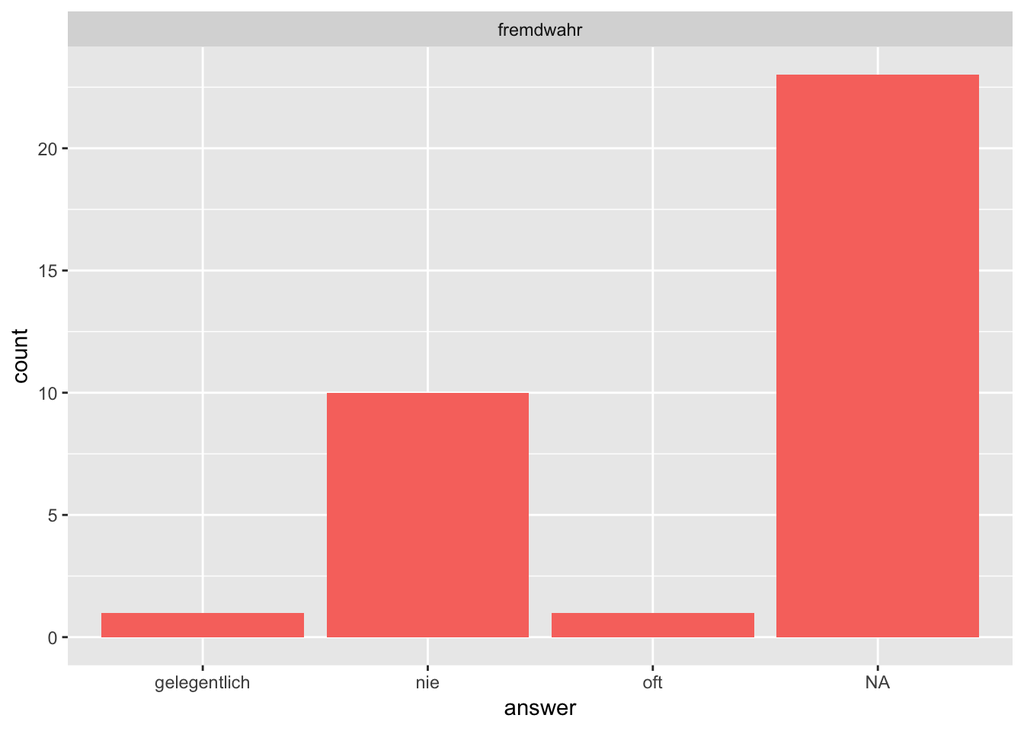

```r
raw1 %>%
      tidy_mc("fremdwahr") %>%
      filter(var == "fremdwahr") %>%
      ggplot(aes(x = answer, fill = var)) +
      geom_bar(position = "dodge") +
      facet_wrap(~ var, scales = "free_x") +
      theme(legend.position = "none")
```

[figure not shown]

```r
fremdwahrbez_frq %>%
      ggplot(aes(x = answer, fill = var)) +
      geom_bar(position = "dodge") +
      facet_wrap(~ var, scales = "free_x") +
      theme(legend.position = "none")
```

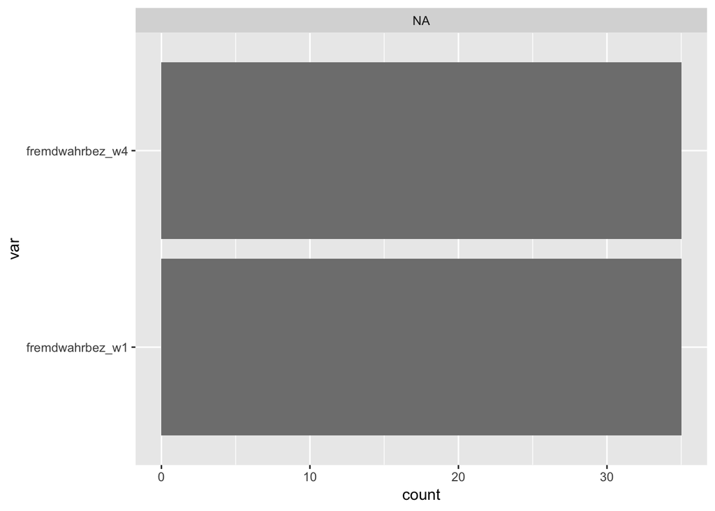

```r
fremdwahrbez_frq %>%
      ggplot(aes(x = var, fill = answer)) +
      geom_bar(position = "dodge") +
      facet_wrap(~ answer) +
      coord_flip() +
      theme(legend.position = "none")
```

#### 1.6.2.3 3. Selbstbezeichnung

[figure not shown]

```r
selbstbez_frq %>%
      ggplot(aes(x = answer, fill = var)) +
      geom_bar(position = "dodge") +
      facet_wrap(~ var, scales = "free_x") +
      theme(legend.position = "none")
```

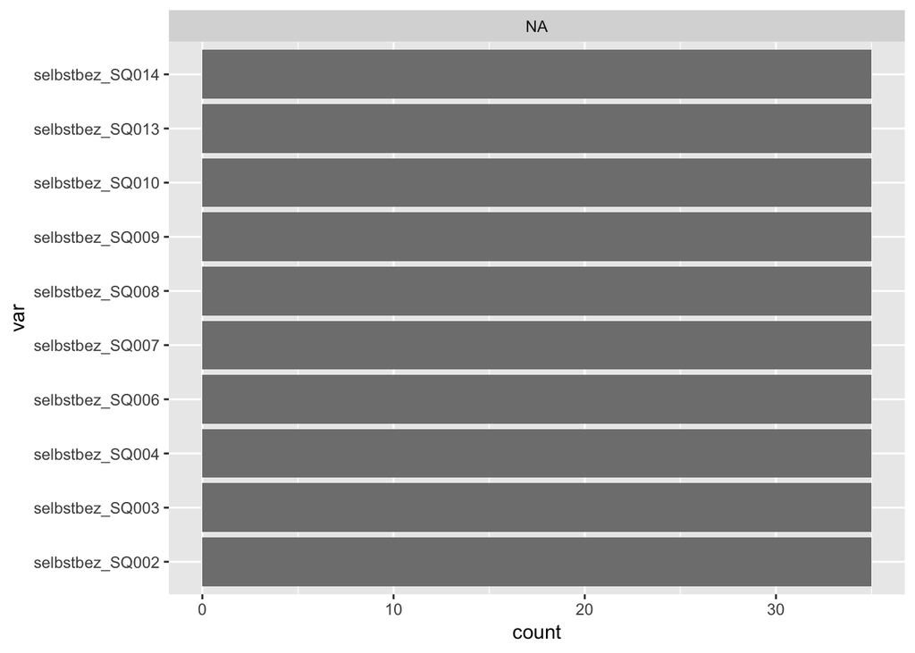

```r
selbstbez_frq %>%
      ggplot(aes(x = var, fill = answer)) +
      geom_bar(position = "dodge") +
      facet_wrap(~ answer) +
      coord_flip() +
      theme(legend.position = "none")
```

### 1.6.3 Rassistische Diskriminierung

**Generate New Variable**

```r
names(rassdisk_subset)
```

```
## [1] "diskallg_SQ005_A1" "diskallg_SQ005_A2" "diskallg_SQ016_A1"
## [4] "diskallg_SQ016_A2"
```

```r
raw7 <- raw6 %>% mutate(
          diskallg = case_when(
            diskallg_SQ005_A1 == "Ja" |
            diskallg_SQ005_A2 == "Ja" |
            diskallg_SQ016_A1 == "Ja" |
            diskallg_SQ016_A2 == "Ja" ~ "rassistische Diskriminierung"),
          fremdwahrbez = case_when(
            (fremdwahr == "gelegentlich" & fremdwahrbez_w1 == "Ja"| fremdwahrbez_w7 == "Ja") |
            (fremdwahr == "oft" & fremdwahrbez_w1 == "Ja" | fremdwahrbez_w7 == "Ja") |
            (fremdwahr == "(fast) imer" & fremdwahrbez_w1 == "Ja"| fremdwahrbez_w7 == "Ja")
                                      ~ "rassistische Diskriminierung"),
          selbstbez = case_when(
                selbstbez_SQ002 == "Ja" |
                selbstbez_SQ003 == "Ja" |
                selbstbez_SQ008 == "Ja" |
                selbstbez_SQ004 == "Ja" |
                selbstbez_SQ006 == "Ja" |
                selbstbez_SQ007 == "Ja" |
                selbstbez_SQ014 == "Ja" |
                selbstbez_SQ010 == "Ja" |
                selbstbez_SQ009 == "Ja" |
                selbstbez_SQ013 == "Ja" ~ "rassistische Diskriminierung"),
          rassdisk = case_when(# Dichotome rassistische Diskriminierungsvariable erstellen
                diskallg == "rassistische Diskriminierung" |
                fremdwahrbez == "rassistische Diskriminierung" |
                selbstbez == "rassistische Diskriminierung" ~ "rassistische Diskriminierung"),
          diskallg = factor(diskallg, c("rassistische Diskriminierung")),
          fremdwahrbez = factor(fremdwahrbez, c("rassistische Diskriminierung")),
          selbstbez = factor(selbstbez, c("rassistische Diskriminierung")),
          rassdisk = factor(rassdisk, c("rassistische Diskriminierung"))
          )

raw7 %>% tabyl(rassdisk)
```

| rassdisk | n | percent | valid_percent |
| --- | --- | --- | --- |
| rassistische Diskriminierung | 3 | 0.0857143 | 1 |
| NA | 32 | 0.9142857 | NA |

## 1.7 Beeinträchtigung

zuerst sehen wir uns die vorhandenen Roh-Daten an, die etwas mit der Dimension Beeinträchtigung des Diversity Profils zu tun haben `beeint`und `beeintwas`

### 1.7.1 Info Raw Data

**Describe Raw Data**

Es gibt Informationen zur generellen Beeinträchtigung `beeint` und ob eine amtliche Behinderung vorliegt `beh`

```r
raw7 %>% count(beeint)
```

| beeint | n |
| --- | --- |
| Ja | 2 |
| Nein | 12 |
| NA | 21 |

```r
raw7 %>% count(beh)
```

| beh | n |
| --- | --- |
| Ja | 2 |
| NA | 33 |

Außerdem Informationen zum Grad der Beeinträchtigung `beeintaus` und der Behinderung `gradbeh` vor. Wir können sehen, dass der Grad der Behinderung als Faktor codiert ist, obwohl er durch einen numerischen Wert besser abgebildet wäre.

```r
raw7 %>% count(beeintaus)
```

| beeintaus | n |
| --- | --- |
| mittel | 1 |
| NA | 34 |

```r
raw7 %>% count(gradbeh)
```

| gradbeh | n |
| --- | --- |
| 50 | 1 |
| 70 | 1 |
| NA | 33 |

```r
raw7 %>% select(beeint, beeintaus, beh, gradbeh) %>% str()
```

```
## 'data.frame':    35 obs. of  4 variables:
##  $ beeint   : Factor w/ 2 levels "Ja","Nein": NA NA NA NA NA NA NA 2 NA NA ...
##  $ beeintaus: Factor w/ 5 levels "sehr stark","stark",..: NA NA NA NA NA NA NA NA NA NA ...
##  $ beh      : Factor w/ 2 levels "Ja","Nein": NA NA NA NA NA NA NA NA NA NA ...
##  $ gradbeh  : Factor w/ 10 levels "20","30","40",..: NA NA NA NA NA NA NA NA NA NA ...
```

```r
raw7 %>% select(beeint, beeintaus, beh, gradbeh) %>% skim()
```

| variable | type | stat | level | value | formatted |
| --- | --- | --- | --- | --- | --- |
| beeint | factor | missing | .all | 21 | 21 |
| beeint | factor | complete | .all | 14 | 14 |
| beeint | factor | n | .all | 35 | 35 |
| beeint | factor | n_unique | .all | 2 | 2 |
| beeint | factor | top_counts | NA | 21 | NA: 21 |
| beeint | factor | top_counts | Nein | 12 | Nei: 12 |
| beeint | factor | top_counts | Ja | 2 | Ja: 2 |
| beeint | factor | ordered | .all | 0 | FALSE |
| beeintaus | factor | missing | .all | 34 | 34 |
| beeintaus | factor | complete | .all | 1 | 1 |
| beeintaus | factor | n | .all | 35 | 35 |
| beeintaus | factor | n_unique | .all | 1 | 1 |
| beeintaus | factor | top_counts | NA | 34 | NA: 34 |
| beeintaus | factor | top_counts | mittel | 1 | mit: 1 |
| beeintaus | factor | top_counts | sehr stark | 0 | seh: 0 |
| beeintaus | factor | top_counts | stark | 0 | sta: 0 |
| beeintaus | factor | top_counts | wenig | 0 | wen: 0 |
| beeintaus | factor | top_counts | überhaupt nicht | 0 | übe: 0 |
| beeintaus | factor | ordered | .all | 0 | FALSE |
| beh | factor | missing | .all | 33 | 33 |
| beh | factor | complete | .all | 2 | 2 |
| beh | factor | n | .all | 35 | 35 |
| beh | factor | n_unique | .all | 1 | 1 |
| beh | factor | top_counts | NA | 33 | NA: 33 |
| beh | factor | top_counts | Ja | 2 | Ja: 2 |
| beh | factor | top_counts | Nein | 0 | Nei: 0 |
| beh | factor | ordered | .all | 0 | FALSE |
| gradbeh | factor | missing | .all | 33 | 33 |
| gradbeh | factor | complete | .all | 2 | 2 |
| gradbeh | factor | n | .all | 35 | 35 |
| gradbeh | factor | n_unique | .all | 2 | 2 |
| gradbeh | factor | top_counts | NA | 33 | NA: 33 |
| gradbeh | factor | top_counts | 50 | 1 | 50: 1 |
| gradbeh | factor | top_counts | 70 | 1 | 70: 1 |
| gradbeh | factor | top_counts | 20 | 0 | 20: 0 |
| gradbeh | factor | top_counts | 30 | 0 | 30: 0 |
| gradbeh | factor | top_counts | 40 | 0 | 40: 0 |
| gradbeh | factor | top_counts | 60 | 0 | 60: 0 |
| gradbeh | factor | top_counts | 80 | 0 | 80: 0 |
| gradbeh | factor | top_counts | 90 | 0 | 90: 0 |
| gradbeh | factor | top_counts | 100 | 0 | 100: 0 |
| gradbeh | factor | top_counts | Ich möchte meine Behinderung nicht näher beschreiben. | 0 | Ich: 0 |
| gradbeh | factor | ordered | .all | 0 | FALSE |

Und spezifisch um welche Beeinträchtigung es sich handelt `beeintwas` Hier gibt es wieder mehrere Variablen, da es sich um eine Mehrfachantwort handelt

```r
frq_mc(data = raw7, "beeintwas")
```

| var | Ja | Nicht Gewählt | NA_ |
| --- | --- | --- | --- |
| beeintwas_SQ001 | 0.00 | 0.06 | 0.94 |
| beeintwas_SQ002 | 0.03 | 0.03 | 0.94 |
| beeintwas_SQ003 | 0.03 | 0.03 | 0.94 |
| beeintwas_SQ004 | 0.00 | 0.06 | 0.94 |
| beeintwas_SQ005 | 0.00 | 0.06 | 0.94 |
| beeintwas_SQ006 | 0.00 | 0.06 | 0.94 |
| beeintwas_SQ007 | 0.00 | 0.06 | 0.94 |
| beeintwas_SQ008 | 0.00 | 0.06 | 0.94 |
| beeintwas_SQ009 | 0.00 | 0.06 | 0.94 |
| beeintwas_SQ010 | 0.03 | 0.03 | 0.94 |
| beeintwas_SQ011 | 0.00 | 0.06 | 0.94 |

```r
frq_mc(data = raw7, "beeintwas", 1)
```

| answer | beeintwas_SQ001 | beeintwas_SQ002 | beeintwas_SQ003 | beeintwas_SQ004 | beeintwas_SQ005 | beeintwas_SQ006 | beeintwas_SQ007 | beeintwas_SQ008 | beeintwas_SQ009 | beeintwas_SQ010 | beeintwas_SQ011 |
| --- | --- | --- | --- | --- | --- | --- | --- | --- | --- | --- | --- |
| Ja | 0 | 1 | 1 | 0 | 0 | 0 | 0 | 0 | 0 | 1 | 0 |
| Nicht Gewählt | 2 | 1 | 1 | 2 | 2 | 2 | 2 | 2 | 2 | 1 | 2 |
| NA | 33 | 33 | 33 | 33 | 33 | 33 | 33 | 33 | 33 | 33 | 33 |

### 1.7.2 Plot Raw Data

**Visualize Raw Data**

Nun sehen wir uns die spezifischen Ausprägungen als Visualisierung an:

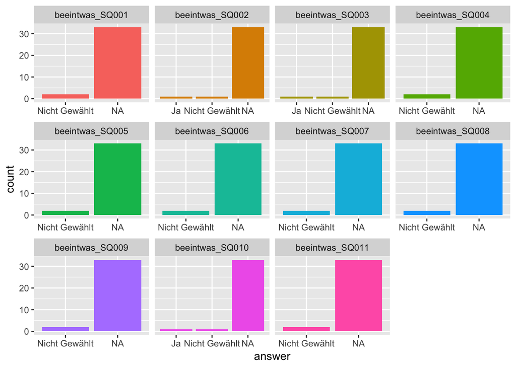

```r
# barplot_mc(raw7, "beeintwas")
frqplot_mc(raw7, "beeintwas")
```

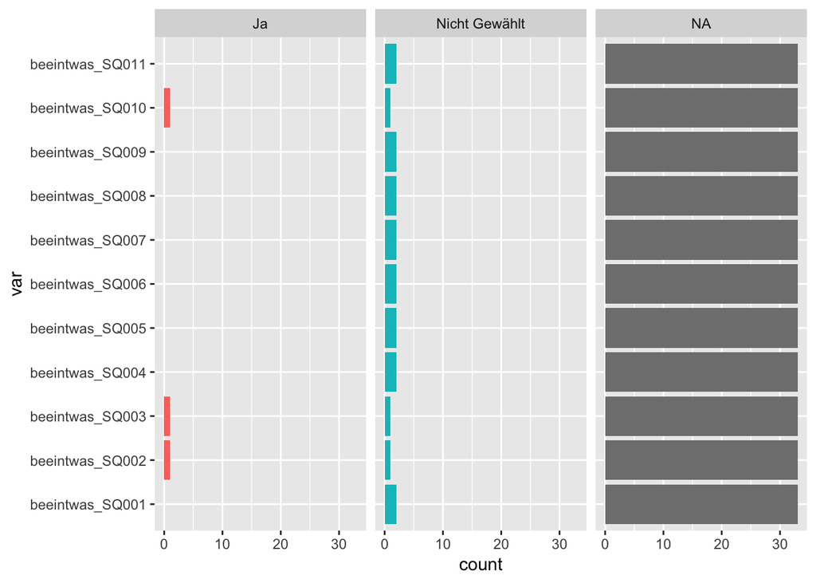

```r
frqplot_mc(raw7, "beeintwas",2)
```

Wir können uns alle Barplots der einzelnen Items `beeintw` zusammengefügt angucken

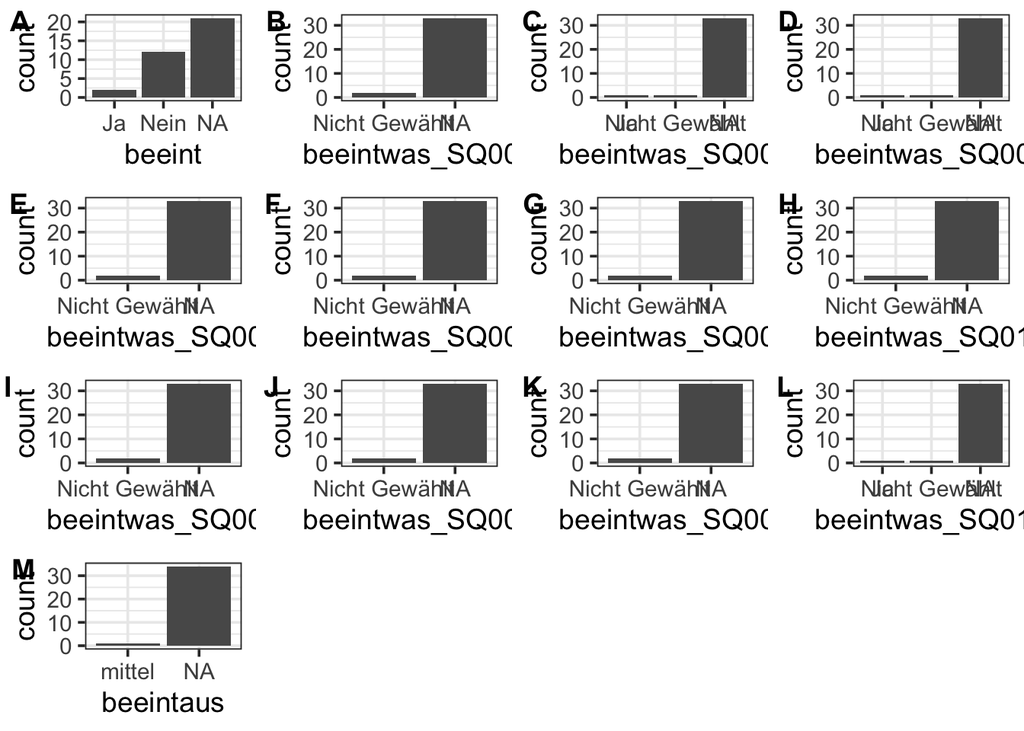

```r
cowplot::plot_grid(plotlist = barplot_mc(raw1, "beeint"),
          labels = "AUTO",
          align = "hv")
```

### 1.7.3 Beeinträchtigung

**Generate New Variable**

Für das Diversity Profile wird eine Variable erstellt, die dichotom zwischen Beeinträchtigung und keine Beeinträchtigung unterscheidet

```r
raw8 <- raw7 %>%
      mutate(# dichotome Variable zur Beeinträchtigung
             beeint_d = case_when(beeint == "Ja" ~ "beeinträchtigt",
                                  beeint == "Nein" ~ "nicht beeinträchtigt",
                                  TRUE ~ NA_character_),
             beeint_d = factor(beeint_d, c("beeinträchtigt", "nicht beeinträchtigt")),
             # keine Angabe auf NULL setzen
             gradbeh = fct_recode(gradbeh, NULL = "Ich möchte meine Behinderung nicht näher beschreiben."),
             # in numerischen vaktor formatieren
             gradbeh = as.numeric(as.character(gradbeh)),
             schwerbeh_d = case_when(gradbeh >= 50 & gradbeh <= 100 ~ "schwerbehindert",
                                  !is.na(gradbeh) & gradbeh < 5 ~ "nicht schwerbehindert",
                                  TRUE ~ NA_character_),
             schwerbeh_d = factor(schwerbeh_d, c("schwerbehindert", "nicht schwerbehindert"))
      )
```

Check neue generierte Variablen

```r
# raw8 %>% select(beeint_d, schwerbeh_d, gradbeh) %>% View()

raw8 %>% select(beeint_d, schwerbeh_d, gradbeh) %>% skim()
```

| variable | type | stat | level | value | formatted |
| --- | --- | --- | --- | --- | --- |
| beeint_d | factor | missing | .all | 21.00000 | 21 |
| beeint_d | factor | complete | .all | 14.00000 | 14 |
| beeint_d | factor | n | .all | 35.00000 | 35 |
| beeint_d | factor | n_unique | .all | 2.00000 | 2 |
| beeint_d | factor | top_counts | NA | 21.00000 | NA: 21 |
| beeint_d | factor | top_counts | nicht beeinträchtigt | 12.00000 | nic: 12 |
| beeint_d | factor | top_counts | beeinträchtigt | 2.00000 | bee: 2 |
| beeint_d | factor | ordered | .all | 0.00000 | FALSE |
| schwerbeh_d | factor | missing | .all | 33.00000 | 33 |
| schwerbeh_d | factor | complete | .all | 2.00000 | 2 |
| schwerbeh_d | factor | n | .all | 35.00000 | 35 |
| schwerbeh_d | factor | n_unique | .all | 1.00000 | 1 |
| schwerbeh_d | factor | top_counts | NA | 33.00000 | NA: 33 |
| schwerbeh_d | factor | top_counts | schwerbehindert | 2.00000 | sch: 2 |
| schwerbeh_d | factor | top_counts | nicht schwerbehindert | 0.00000 | nic: 0 |
| schwerbeh_d | factor | ordered | .all | 0.00000 | FALSE |
| gradbeh | numeric | missing | .all | 33.00000 | 33 |
| gradbeh | numeric | complete | .all | 2.00000 | 2 |
| gradbeh | numeric | n | .all | 35.00000 | 35 |
| gradbeh | numeric | mean | .all | 60.00000 | 60 |
| gradbeh | numeric | sd | .all | 14.14214 | 14.14 |
| gradbeh | numeric | p0 | .all | 50.00000 | 50 |
| gradbeh | numeric | p25 | .all | 55.00000 | 55 |
| gradbeh | numeric | p50 | .all | 60.00000 | 60 |
| gradbeh | numeric | p75 | .all | 65.00000 | 65 |
| gradbeh | numeric | p100 | .all | 70.00000 | 70 |
| gradbeh | numeric | hist | .all | NA | ▇▁▁▁▁▁▁▇ |

```r
raw8 %>% tabyl(beeint_d)
```

| beeint_d | n | percent | valid_percent |
| --- | --- | --- | --- |
| beeinträchtigt | 2 | 0.0571429 | 0.1428571 |
| nicht beeinträchtigt | 12 | 0.3428571 | 0.8571429 |
| NA | 21 | 0.6000000 | NA |

```r
raw8 %>% tabyl(schwerbeh_d)
```

| schwerbeh_d | n | percent | valid_percent |
| --- | --- | --- | --- |
| schwerbehindert | 2 | 0.0571429 | 1 |
| nicht schwerbehindert | 0 | 0.0000000 | 0 |
| NA | 33 | 0.9428571 | NA |

```r
raw8 %>% tabyl(beeint_d, schwerbeh_d)
```

| beeint_d | schwerbehindert | nicht schwerbehindert | NA_ |
| --- | --- | --- | --- |
| beeinträchtigt | 2 | 0 | 0 |
| nicht beeinträchtigt | 0 | 0 | 12 |
| NA | 0 | 0 | 21 |

## 1.8 SES

zuerst sehen wir uns die vorhandenen Roh-Daten an, die etwas mit der Dimension Sozioökonomischer Status des Diversity Profils zu tun haben

### 1.8.1 Info Raw Data

**Describe Raw Data**

#### 1.8.1.1 SSS

Hier gibt es Informationen in Bezug auf den subjektiven sozialen Status (sss) `sozstatus`. Die Variable sollte auch von Faktor zu metrischem Vektor umgewandelt werden.

```r
raw8 %>% count(sozstatus)
```

| sozstatus | n |
| --- | --- |
| 8 | 7 |
| 7 | 2 |
| 6 | 3 |
| 3 | 1 |
| NA | 22 |

```r
raw8 %>% select(sozstatus) %>% str()
```

```
## 'data.frame':    35 obs. of  1 variable:
##  $ sozstatus: Factor w/ 10 levels "10","9","8","7",..: NA NA NA NA NA NA NA 5 NA NA ...
```

#### 1.8.1.2 Einkommen

Außerdem gibt es Informationen zum Einkommen `einkgr`und `neteink`

```r
raw8 %>% count(einkgr)
```

| einkgr | n |
| --- | --- |
| 816 – 921 | 1 |
| 1418 – 1619 | 1 |
| 1620 – 1833 | 1 |
| 1834 – 2125 | 2 |
| 2126 – 2692 | 4 |
| 2693 – 3500 | 1 |
| 3501 – 5000 | 2 |
| 5001 € oder mehr | 1 |
| NA | 22 |

```r
# raw8 %>% count(neteink)
```

#### 1.8.1.3 Beruf

Und Informationen zum Berufsstatus `aktberuf`

```r
raw8 %>% count(aktberuf)
```

| aktberuf | n |
| --- | --- |
| Meister_in | 1 |
| Beamte_r im mittleren Dienst | 1 |
| Beamte_r im höheren Dienst (z.B. Staatssekretär_in); Richter_in | 2 |
| Angestellte_r mit ausführender Tätigkeit (z.B. Bürobot_in, Postverteiler_in) | 1 |
| Angestellte_r mit qualifizierter Tätigkeit (z.B. Sachbearbeiter_in, Buchhalter_in) | 5 |
| Angestellte_r mit hochqualifizierter Tätigkeit (wissenschaftliche_r Mitarbeiter_in, Abteilungsleiter_in) | 2 |
| NA | 23 |

#### 1.8.1.4 Bildung

Und Informationen zur Bildung: den Bildungsabschluss `bildab` und Anzahl der Schuljahre `bildneu`und `bildalt`

```r
raw8 %>%
      select_mc("bild", id = 0) %>%
      map(~count(data.frame(x =.x), x))
```

```
## $bildalt_SQ001
## # A tibble: 6 x 2
##       x     n
##   <dbl> <int>
## 1     8     2
## 2     9     1
## 3    11     1
## 4    12     3
## 5    15     4
## 6    NA    24
##
## $bildneu_SQ021
## # A tibble: 6 x 2
##       x     n
##   <dbl> <int>
## 1     2     1
## 2     5     1
## 3     8     2
## 4     9     2
## 5    15     1
## 6    NA    28
##
## $bildab
## # A tibble: 7 x 2
##   x                                                                  n
##   <fct>                                                          <int>
## 1 Mittlere Reife oder POS-Abschluss und berufliche Ausbildung        2
## 2 Fachhochschulreife/Abitur, EOS7und keine berufliche Ausbildung     1
## 3 Fachhochschulreife/Abitur, EOS und berufliche Ausbildung           1
## 4 Fachhochschulabschluss                                             3
## 5 Hochschulabschluss                                                 5
## 6 Promotion und / oder Habilitation                                  1
## 7 <NA>                                                              22
```

#### 1.8.1.5 Lebenssituation

Informationen zur Lebenssituation `lebsit`

```r
raw8 %>% frq_mc("lebsit")
```

| var | Ja | Nicht Gewählt | NA_ |
| --- | --- | --- | --- |
| lebsit_SQ002 | 0.06 | 0.40 | 0.54 |
| lebsit_SQ003 | 0.03 | 0.43 | 0.54 |
| lebsit_SQ004 | 0.03 | 0.43 | 0.54 |
| lebsit_SQ005 | 0.06 | 0.40 | 0.54 |
| lebsit_SQ006 | 0.06 | 0.40 | 0.54 |
| lebsit_SQ007 | 0.06 | 0.40 | 0.54 |
| lebsit_SQ008 | 0.03 | 0.43 | 0.54 |

Lasst uns die Variablen Labels der verschiedenen Variablen ansehen

```r
cat(paste0("Variable ",
       # filter für variablennamen die "lebsit" enthalten
       names(raw1)[grepl("lebsit", attributes(raw1)$names)], ": \n",
       # filter für die passenden variablen labels
       attributes(raw1)$variable.labels[grepl("lebsit", attributes(raw1)$names)]," \n \n")
    )
```

```
## Variable lebsit_SQ002:
## [Single] Welche Lebenssituation trifft auf Sie zu?
##
##  Variable lebsit_SQ003:
## [Alleinerziehend mit einem Kind] Welche Lebenssituation trifft auf Sie zu?
##
##  Variable lebsit_SQ004:
## [Alleinerziehend mit zwei oder mehr Kinder] Welche Lebenssituation trifft auf Sie zu?
##
##  Variable lebsit_SQ005:
## [Paar] Welche Lebenssituation trifft auf Sie zu?
##
##  Variable lebsit_SQ006:
## [Paar mit einem Kind] Welche Lebenssituation trifft auf Sie zu?
##
##  Variable lebsit_SQ007:
## [Paar mit zwei oder mehr Kindern] Welche Lebenssituation trifft auf Sie zu?
##
##  Variable lebsit_SQ008:
## [Pflegende_r Angehörige_r] Welche Lebenssituation trifft auf Sie zu?
##
##  Variable lebsit_other:
## [Sonstiges] Welche Lebenssituation trifft auf Sie zu?
##
```